# Rasters.jl

Geospatial raster data reading, writing and manipulation

Rafael Schouten

rafaelschouten@gmail.com

Globe Intstitute, Copenhagen University

2024-07-10

# What is a raster?

[figure not shown]

- like an image, but not RGB
- values of some variable accross a gridded space
- usually has X/Y spatial dimensions
  - (e.g. lattitude/longitude)
- with a coordinate reference system

[figure not shown]

- may be collected in a dataset with multiple variables
- may have more dimensions, like time

# DimensionalData.jl integration

- Rasters extends DimensionalData.jl
  - `Raster <: AbstractDimArray` and `RasterStack <: AbstractDimStack`
- This gives is the foundation for spatial work
- Rasters adds:
  - coordinate reference systems
  - missing value handling
  - File IO
  - GIS tools

## File Read/Write Backends

| File types | Package |
| --- | --- |
| Netcdf/hdf5 | NCDatasets.jl |
| Grib (read only) | GRIBDatasets.jl |
| Zarr (PR nearly done!) | ZarrDatasets.jl |
| grd (simple Mmap data from R) | native |
| GeoTIFF and everything else | ArchGDAL.jl |

## Backend detection

Backend detected in constructors:

```julia
# Single array
rast = Raster("myraster.tif")    # Will use ArchGDAL.jl
rast = Raster("myraster.nc")     # Will use NCDatasets

# Multi-array
st = RasterStack("mystack.nc")   # Will use NCDatasets.jl
st = RasterStack("mystack.grib") # Will use GRIBDatasets.jl
```

# DiskArrays.jl integration

For larger-than-memory data

## Lazy loading

```julia
rast = Raster(filename; lazy=true)
```

Still lazy after broadcasts:

```julia
rast10 = rast .* 10
```

Reads from disk/network only on `getindex`:

```julia
rast10[X=100 .. 135, Y=20 .. 40]
```

## Chunk patterns

For more efficient lazy reads:

```julia
write("rechunked.tif", mem_rast; chunks=(X(256), Y(256)))
```

## RasterDataSources.jl integration

```
"."
```

Load a raster from RasterDataSources.jl filename:

```julia
using Rasters, RasterDataSources, ArchGDAL
bioclim_filename = RasterDataSources.getraster(WorldClim{BioClim}, 5)
bioclim5 = Raster(bioclim_filename);
```

[output not shown]

Or use RasterDataSources.jl syntax directly:

```julia
bioclim_filename = Raster(WorldClim{BioClim}, 5);
```

# Plotting

Always the right way up!

## Plots.jl

```julia
using Plots
Plots.plot(bioclim5)
```

[figure not shown]

## Makie.jl

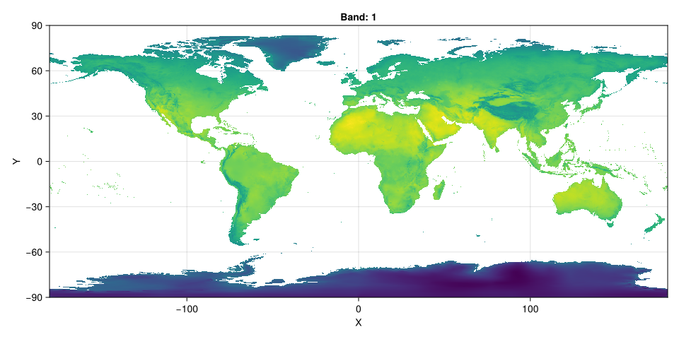

```julia
using CairoMakie
Makie.plot(bioclim5)
```

## GeoMakie.jl

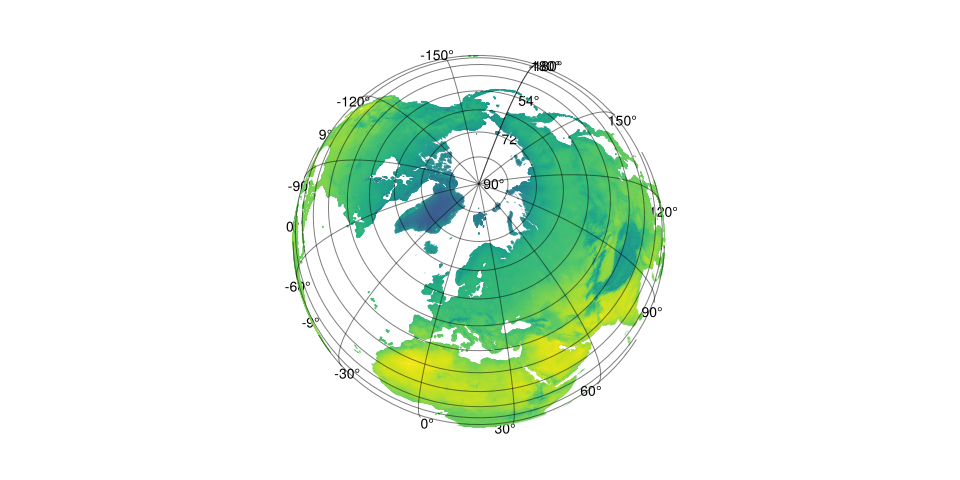

```julia
using GeoMakie
fig = Figure();
ga = GeoAxis(fig[1, 1]; dest="+proj=ortho +lon_0=19 +lat_0=72")
Makie.heatmap!(ga, bioclim5)
fig
```

# Common GIS methods

- for working with raster data
- for using vector/geometry data with raster data

## Native rasterization engine

- accepts all GeoInterface.jl geometries
- extremely fast + threaded
- detailed correctness warnings
- consistent behaviour and syntax for:
- `rasterize`
- `coverage`
- `mask`
- `boolmask`/`missingmask`
- `zonal`

## Other common methods

- extract
- crop/extend
- trim
- mosaic
- aggregate
- resample

# Examples

```julia
using Rasters
using ArchGDAL
using Dates
using DataFrames
using GBIF2
using NaturalEarth
using RasterDataSources
```

## `extract`

Extract climate data at specific points:

```julia
clim = RasterStack(WorldClim{BioClim})
occ = GBIF2.occurrence_search("Burramys parvus")
# occ is a table with a `:geometry` column, so this "just works"
extract(clim, occ; name=(:bio1, :bio4, :bio7)) |> DataFrame
```

20×4 DataFrame

| Row | geometry Tuple…? | bio1 Float32? | bio4 Float32? | bio7 Float32? |
| --- | --- | --- | --- | --- |
| 1 | missing | missing | missing | missing |
| 2 | (148.396, -36.3818) | 6.88158 | 484.889 | 23.133 |
| 3 | missing | missing | missing | missing |
| 4 | (148.333, -36.4333) | 7.83572 | 492.505 | 23.5028 |
| 5 | (148.329, -36.4317) | 7.83572 | 492.505 | 23.5028 |
| 6 | (148.391, -36.3036) | 6.1707 | 502.798 | 23.4645 |
| 7 | missing | missing | missing | missing |
| 8 | (147.096, -36.9357) | 9.40835 | 492.567 | 23.0895 |
| 9 | (148.347, -36.5047) | 8.4207 | 470.417 | 23.142 |
| 10 | missing | missing | missing | missing |
| 11 | missing | missing | missing | missing |
| 12 | missing | missing | missing | missing |
| 13 | (148.241, -36.4001) | 7.83572 | 492.505 | 23.5028 |
| 14 | (148.236, -36.5249) | 8.0016 | 479.975 | 22.8522 |
| 15 | missing | missing | missing | missing |
| 16 | missing | missing | missing | missing |
| 17 | missing | missing | missing | missing |
| 18 | (147.1, -37.0) | 8.25414 | 485.855 | 22.2347 |
| 19 | missing | missing | missing | missing |
| 20 | missing | missing | missing | missing |

## `mask` + `trim`

Mask climate rasters wth country border :

```julia
clim = RasterStack(WorldClim{Climate}, (:tmin, :tmax, :prec, :wind); month=July)
countries = naturalearth("ne_10m_admin_0_countries") |> DataFrame
finland = subset(countries, :NAME => ByRow(==("Finland"))).geometry
finland_clim = mask(clim; with=finland) |> trim
Plots.plot(finland_clim; size=(800, 400))
```

[output not shown]

[output cut: 229 more lines]

[output not shown]

[figure not shown]

## `zonal` statistics

Find the hottest and coldest countries in July:

```julia
clim = Raster(WorldClim{Climate}, :tmax; month=July)
countries = naturalearth("ne_10m_admin_0_countries") |> DataFrame
countries.july_maxtemp = zonal(Statistics.mean, clim;
    of=countries, boundary=:touches, progress=false
)
filtered = subset(countries, :july_maxtemp => ByRow(!isnan))
sort!(filtered, :july_maxtemp).NAME
```

```
254-element Vector{String}:
 "Antarctica"
 "Greenland"
 "Southern Patagonian Ice Field"
 "S. Geo. and the Is."
 "Heard I. and McDonald Is."
 "Falkland Is."
 "Fr. S. Antarctic Lands"
 "Siachen Glacier"
 "Chile"
 "New Zealand"
 ⋮
 "Bir Tawil"
 "Bahrain"
 "Mauritania"
 "Algeria"
 "Qatar"
 "Saudi Arabia"
 "United Arab Emirates"
 "Iraq"
 "Kuwait"
```

## Thanks

Especially to Rasters.jl contributors!

[figure not shown]

Any problems, make github issues at  
https://github.com/rafaqz/Rasters.jl  
(Please include all files in a MWE!)